# Tarea 3

Aslie Cárdenas Sandoval

2024-08-20

## Parte I

En este ejercicio vamos a usar la tabla de datos SpotifyTop2018_40_V2.csv, que contiene una lista de 40 de las canciones más reproducidas en Spotify en el año 2018. Los datos incluyen una serie de características importantes del audio de cada canción.

#### Ejercicio 1.a

Calcule el resumen numérico, interprete los resultados para dos variables.

```r
datos.spotify <- read.table("./DatosTarea3/SpotifyTop2018_40_V2.csv", header = TRUE, sep = ",",dec='.')
summary(datos.spotify)
```

```
##   danceability        energy          loudness       speechiness
##  Min.   :0.2580   Min.   :0.3910   Min.   :-9.211   Min.   :0.02320
##  1st Qu.:0.6805   1st Qu.:0.5643   1st Qu.:-7.077   1st Qu.:0.04955
##  Median :0.7500   Median :0.6590   Median :-5.930   Median :0.10550
##  Mean   :0.7192   Mean   :0.6619   Mean   :-5.846   Mean   :0.12129
##  3rd Qu.:0.8175   3rd Qu.:0.7725   3rd Qu.:-4.624   3rd Qu.:0.14450
##  Max.   :0.9220   Max.   :0.9090   Max.   :-3.093   Max.   :0.51600
##   acousticness      instrumentalness       liveness          valence
##  Min.   :0.000282   Min.   :0.000e+00   Min.   :0.02150   Min.   :0.0967
##  1st Qu.:0.030800   1st Qu.:0.000e+00   1st Qu.:0.09527   1st Qu.:0.2875
##  Median :0.121500   Median :3.220e-06   Median :0.11200   Median :0.4375
##  Mean   :0.184621   Mean   :3.695e-03   Mean   :0.17713   Mean   :0.4679
##  3rd Qu.:0.227500   3rd Qu.:4.325e-05   3rd Qu.:0.29475   3rd Qu.:0.6332
##  Max.   :0.847000   Max.   :1.340e-01   Max.   :0.55200   Max.   :0.9310
##      tempo         duration_ms     time_signature
##  Min.   : 77.17   Min.   : 95467   Min.   :3.00
##  1st Qu.: 95.04   1st Qu.:189856   1st Qu.:4.00
##  Median :122.53   Median :212905   Median :4.00
##  Mean   :122.11   Mean   :205646   Mean   :3.95
##  3rd Qu.:140.59   3rd Qu.:226983   3rd Qu.:4.00
##  Max.   :191.70   Max.   :268867   Max.   :4.00
```

#### Ejercicio 1.b

Realice un gráfico de dispersión e interprete dos similitudes en el gráfico.

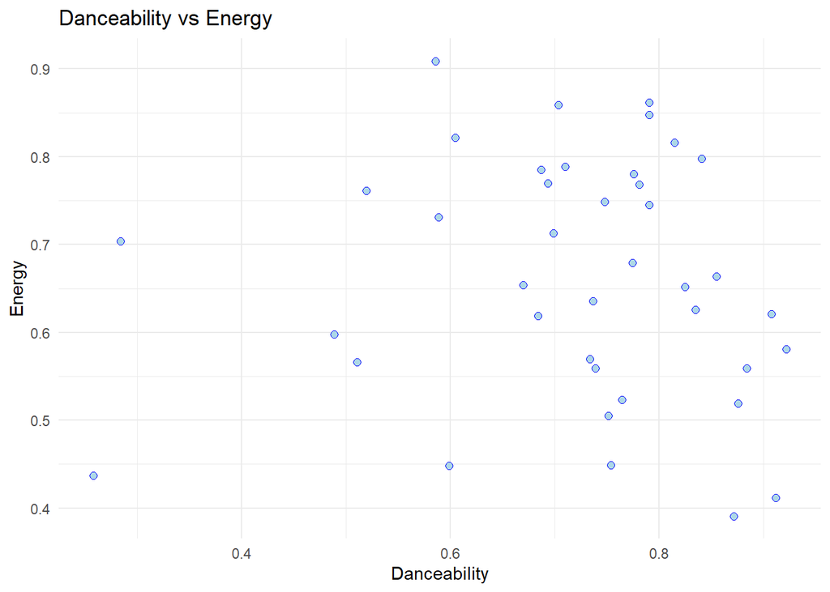

```r
library(ggplot2)
ggplot(datos.spotify, aes(x = danceability, y = energy)) +
  geom_point(color = "blue", fill = "lightblue", shape=21, size=2) +
  labs(x = "Danceability", y = "Energy", title = "Danceability vs Energy") +
  theme_minimal()
```

#### Ejercicio 1.c

Para dos variables identifique los datos atípicos, si los hay.

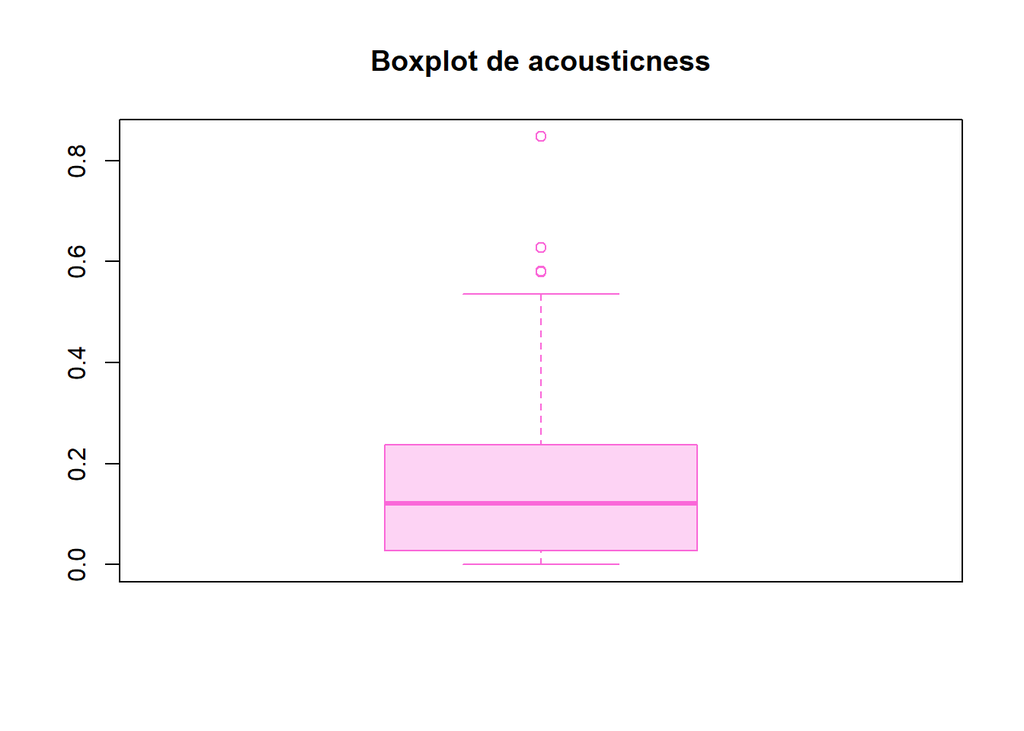

```r
boxplot(datos.spotify$acousticness, main = "Boxplot de acousticness", col = "#fdd3f4", border = "#fa68d8")
```

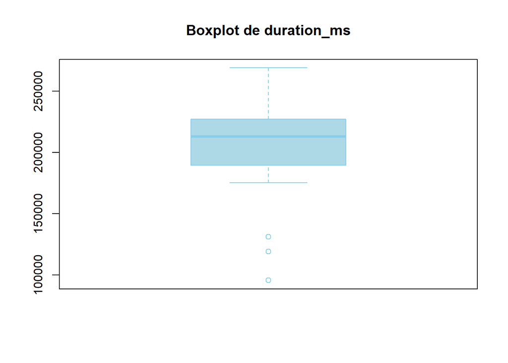

```r
boxplot(datos.spotify$duration_ms, main = "Boxplot de duration_ms", col = "lightblue", border = "skyblue")
```

#### Ejercicio 1.d

Calcule la matriz de correlaciones, incluya alguna de las imágenes que ofrece R e interpréte dos de las correlaciones. Debe ser una interpretación dirigida a una persona que no sabe nada de estadística.

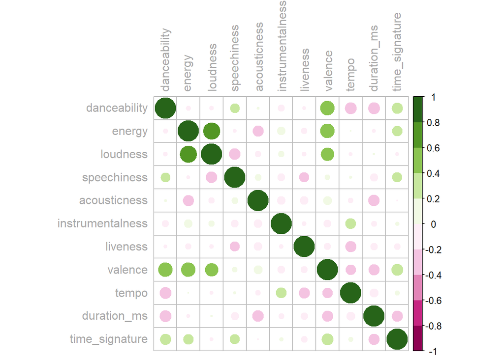

```r
library(corrplot)
matriz.correlacion <- cor(datos.spotify)
corrplot(matriz.correlacion, col = COL2("PiYG", 10), tl.col = "darkgrey")
```

Interpretación:

- Hay correlación fuerte y positiva entre loudness y energy, lo que significa que las canciones con volumen más alto tienden a ser más enérgeticas.
- Tempo y danceability tienen correlación negativa, lo que sugiere que si la velocidad de la canción aumenta la capacidad de baile disminuye, mientras más rápida la canción, menos fácil de bailar.

#### Ejercicio 1.e

Efectúe un ACP y dé una interpretación siguiendo los siguientes pasos:

```r
library("FactoMineR")
library("factoextra")
```

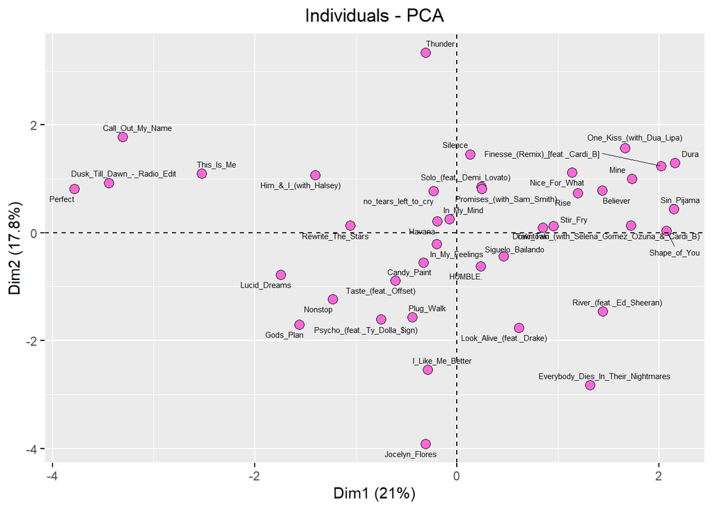

```r
mi.tema <- theme_grey() + theme(panel.border = element_rect(fill = NA,color = "white"), plot.title = element_text(hjust = 0.5))

acp.resultado <- PCA(datos.spotify, scale.unit = TRUE, ncp = 5, graph = FALSE)

fviz_pca_ind(acp.resultado, pointsize = 3, pointshape = 21, fill = "#fa68d8", repel = TRUE,ggtheme = mi.tema, labelsize = 2)
```

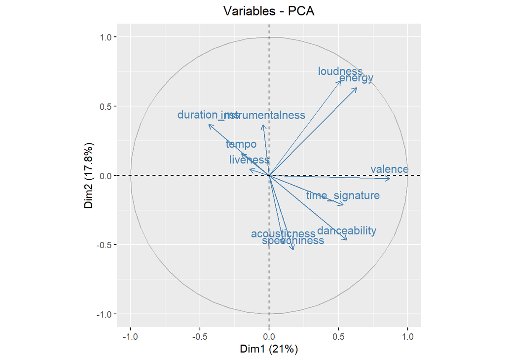

```r
fviz_pca_var(acp.resultado, col.var = "steelblue", ggtheme = mi.tema)
```

Individuos y variables mal representados:

```r
cos2.ind <- (acp.resultado$ind$cos2[,1]+acp.resultado$ind$cos2[,2])*100
cos2.ind
```

```
##                                          Dura
##                                     54.704337
##                                     Plug_Walk
##                                     42.102176
##                                       Silence
##                                     29.417303
##                      Solo_(feat._Demi_Lovato)
##                                     17.500302
##                                    Sin_Pijama
##                                     62.570382
##                              Call_Out_My_Name
##                                     52.220981
## Taki_Taki_(with_Selena_Gomez_Ozuna_&_Cardi_B)
##                                     49.432002
##                      River_(feat._Ed_Sheeran)
##                                     19.989875
##                             Rewrite_The_Stars
##                                     39.983100
##                         Him_&_I_(with_Halsey)
##                                     34.556546
##                      Look_Alive_(feat._Drake)
##                                     42.533191
##                                          Rise
##                                     49.351703
##                                       Perfect
##                                     51.504479
##                                       Thunder
##                                     24.672296
##                  Psycho_(feat._Ty_Dolla_$ign)
##                                     44.957001
##                          no_tears_left_to_cry
##                                     28.623298
##            Everybody_Dies_In_Their_Nightmares
##                                     41.709185
##                                Jocelyn_Flores
##                                     75.099260
##                                       HUMBLE.
##                                      9.305416
##                                    In_My_Mind
##                                      2.035797
```

[output cut: 25 more lines]

```
##                                     78.987621
##               Finesse_(Remix)_[feat._Cardi_B]
##                                     60.585350
##                                       Nonstop
##                                     29.109867
##                                          Mine
##                                     27.646096
##                                In_My_Feelings
##                                      1.546836
##                          Taste_(feat._Offset)
##                                     21.411214
##                                  Lucid_Dreams
##                                     36.384022
##                     Promises_(with_Sam_Smith)
##                                     19.641199
```

```r
cos2.var <-(acp.resultado$var$cos2[,1]+acp.resultado$var$cos2[,2])*100
cos2.var
```

```
##     danceability           energy         loudness      speechiness
##        53.301090        80.319159        73.272885        31.886269
##     acousticness instrumentalness         liveness          valence
##        25.027230        13.722773         2.172748        75.826655
##            tempo      duration_ms   time_signature
##         6.465615        32.639244        33.072360
```

1. Elimine de los gráficos individuos y variables con menos del 5 % de calidad de representación.

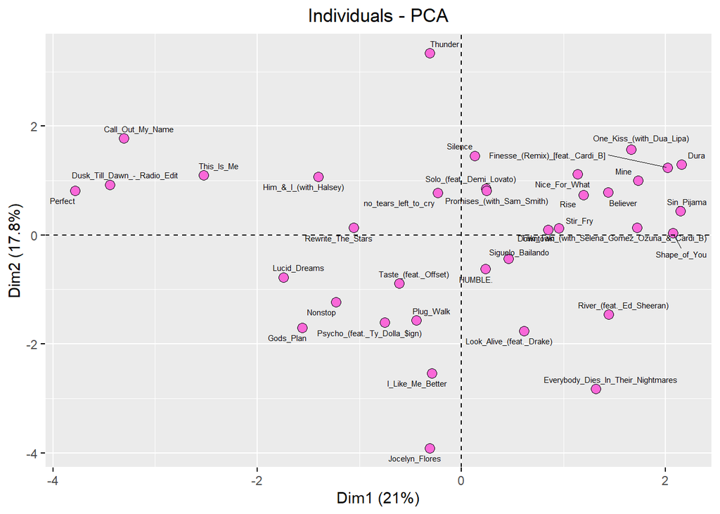

```r
fviz_pca_ind(acp.resultado, pointsize = 3, pointshape = 21, fill = "#fa68d8", repel = TRUE,ggtheme = mi.tema, labelsize = 2, select.ind = list(cos2 = 0.05))
```

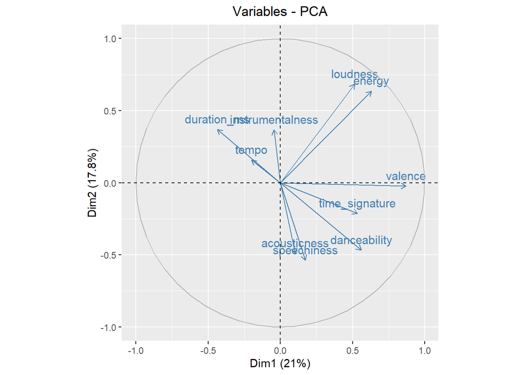

```r
fviz_pca_var(acp.resultado, col.var = "steelblue", ggtheme = mi.tema, select.var = list(cos2 = 0.05))
```

2. En el círculo de correlación determine la correlación entre las variables.
   - loudness y energy tienen correlación positiva, a medida que la sonoridad (loudness) de una pista aumenta, también lo hace su energía.
   - time_signature y danceability tienen correlación positiva, canciones con beats de tiempo son más complejas para bailar.
   - acousticness y speechiness tienen correlación positiva, las canciones que son más acústicas más voz.
   - tempo y durabilidad tienen correlación negativa con danceablility, acousticness y speechiness, un tempo más rápido o más lento está asociado con una menor capacidad para bailar
   - instrumentalness tiene correlación negativa con acousticness y speechiness, a medida que una pista se vuelve más instrumental suele tener menos características acústicas y una menor presencia de palabras.
3. Explique la formación de los clústeres basado en la sobre-posición del círculo y el plano.
   - Canciones que están el el cluster de arriba entre el centro y a la derecha, como Tunder, Solo, Rise, One Kiss son altas en lounness, energy y valence, por lo son energeticas y alegres.
   - Las canciones que estan en el cluster de abajo abajo, como I like me better, taste, psycho, plug walk, etc, son altas en acousticness, speechiness y danceability, indicando que son más acústicas y bailables.
   - Las canciones que estan en el cluster de arriba a la izquierda, como This is me, him & I y Perfect, son altas en tempo, instrumentalness y duracion en ms, pero son menos bailables y acústicas.
4. En el plano de los componentes 1 y 3 interprete las canciones In My Feelings, In My Mind, Havana, Candy Paint y HUMBLE, que son mal representadas en los componentes 1 y 2.

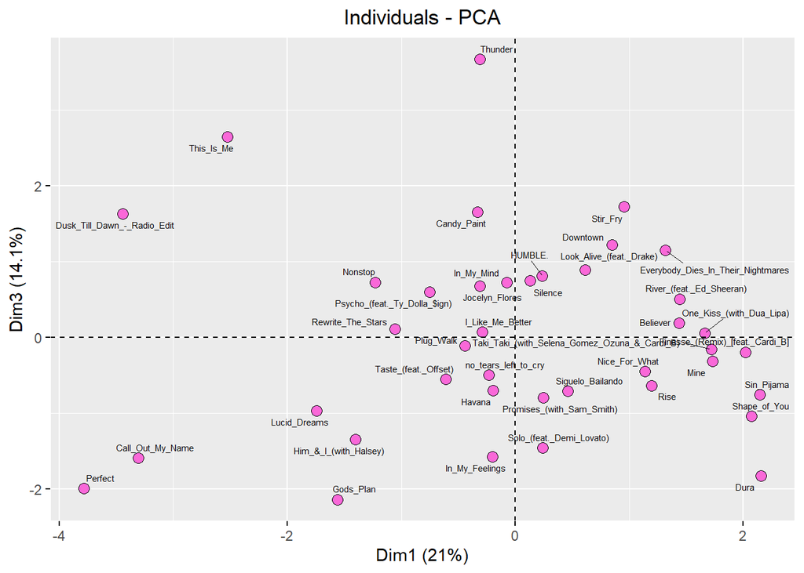

```r
fviz_pca_ind(acp.resultado, axes = c(1, 3), pointsize = 3, pointshape = 21, fill = "#fa68d8", repel = TRUE, ggtheme = mi.tema, labelsize = 2)
```

- In My Mind, Candy Paint y HUMBLE, están en el cluster de arriba donde el volumen, energia son altas, también el instrumentalness.
- In My Feelings, Havana, están en el cluster de abajo, donde acousticness, speechiness y danceablity son altas.

## Parte II

En este ejercicio vamos a usar los datos TablaAffairs.csv, los cuales recopilan información sobre infidelidades en parejas casadas, como lo es la edad de la persona, años de casado y el nivel de educación.

#### Ejercicio 2.a

Calcule el resumen numérico, interprete los resultados para una variable.

```r
datos.infieles <- read.table("./DatosTarea3/TablaAffairs.csv", header = TRUE, sep = ";",dec='.', stringsAsFactors = TRUE)
#Quitamos categóricas
datos.infieles <- datos.infieles[,-c(1, 3, 6, 10)]

str(datos.infieles)
```

```
## 'data.frame':    601 obs. of  6 variables:
##  $ TiempoInfiel: int  0 0 0 0 0 0 0 0 0 0 ...
##  $ Edad        : num  37 27 32 57 22 32 22 57 32 22 ...
##  $ AnnosCasado : num  10 4 15 15 0.75 1.5 0.75 15 15 1.5 ...
##  $ Religioso   : num  2.98 4.16 0.97 4.53 1.66 1.58 2.13 2.03 3.66 4.05 ...
##  $ Educacion   : num  17.8 13.4 12.7 17.8 16.9 ...
##  $ Ocupacion   : int  7 6 1 6 6 5 1 4 1 4 ...
```

```r
summary(datos.infieles)
```

```
##   TiempoInfiel         Edad        AnnosCasado       Religioso
##  Min.   : 0.000   Min.   :17.50   Min.   : 0.125   Min.   :0.510
##  1st Qu.: 0.000   1st Qu.:27.00   1st Qu.: 4.000   1st Qu.:2.110
##  Median : 0.000   Median :32.00   Median : 7.000   Median :3.200
##  Mean   : 1.456   Mean   :32.49   Mean   : 8.178   Mean   :3.128
##  3rd Qu.: 0.000   3rd Qu.:37.00   3rd Qu.:15.000   3rd Qu.:4.140
##  Max.   :12.000   Max.   :57.00   Max.   :15.000   Max.   :5.490
##    Educacion       Ocupacion
##  Min.   : 8.89   Min.   :1.000
##  1st Qu.:14.27   1st Qu.:3.000
##  Median :16.39   Median :5.000
##  Mean   :16.19   Mean   :4.195
##  3rd Qu.:17.86   3rd Qu.:6.000
##  Max.   :20.50   Max.   :7.000
```

- El promedio de la variable edad es de 32 años.
- El promedio de los años que llevan casados los individuos es de 8 años.

#### Ejercicio 2.b

Calcule la matriz de correlaciones, incluya alguna de las imágenes que ofrece R e interpréte dos de las correlaciones. Debe ser una interpretación dirigida a una persona que no sabe nada de estadística.

```r
correlacion.infieles <- cor(datos.infieles)
correlacion.infieles
```

```
##              TiempoInfiel      Edad AnnosCasado   Religioso   Educacion
## TiempoInfiel   1.00000000 0.0952372  0.18684169 -0.13750101 -0.01033040
## Edad           0.09523720 1.0000000  0.77754585  0.17895211  0.13038951
## AnnosCasado    0.18684169 0.7775458  1.00000000  0.20026108  0.03020485
## Religioso     -0.13750101 0.1789521  0.20026108  1.00000000 -0.02142343
## Educacion     -0.01033040 0.1303895  0.03020485 -0.02142343  1.00000000
## Ocupacion      0.04961176 0.1664125  0.04459201 -0.02838681  0.53474365
##                Ocupacion
## TiempoInfiel  0.04961176
## Edad          0.16641254
## AnnosCasado   0.04459201
## Religioso    -0.02838681
## Educacion     0.53474365
## Ocupacion     1.00000000
```

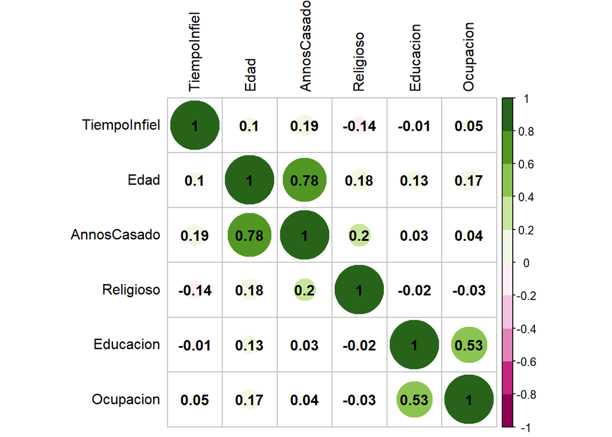

```r
corrplot(correlacion.infieles, addCoef.col = 'black', col = COL2("PiYG", 10), tl.col = "black")
```

Interpretación:

- Hay correlación fuerte y positiva entre la edad y los años de casados. Entre más edad tiene la persona, los años de casado también aumentan.
- Entre tiempo infiel y años de casado también hay correlación positiva, significa que entre más años de casado hay más posibilidad que haya pasado más tiempo siendo infiel.
- Timpo infiel tiene correlación negativa con Religioso, lo que puede suponer que las personas más religiosas tienden a ser menos infieles y viceversa.

#### Ejercicio 2.c

Usando solo las variables numéricas efectúe un ACP.

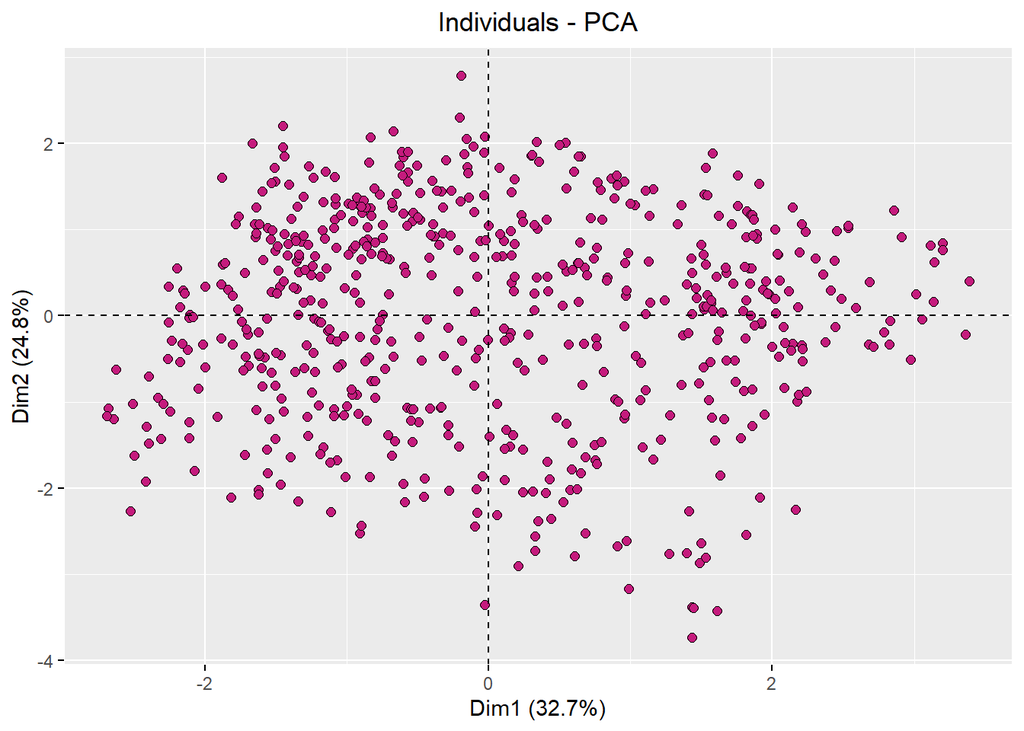

```r
acp.infieles <- PCA(datos.infieles, scale.unit = TRUE, ncp = 5, graph = FALSE)

fviz_pca_ind(acp.infieles, pointsize = 2, pointshape = 21, fill = "#C51B7D", repel = TRUE,ggtheme = mi.tema, label = "none")
```

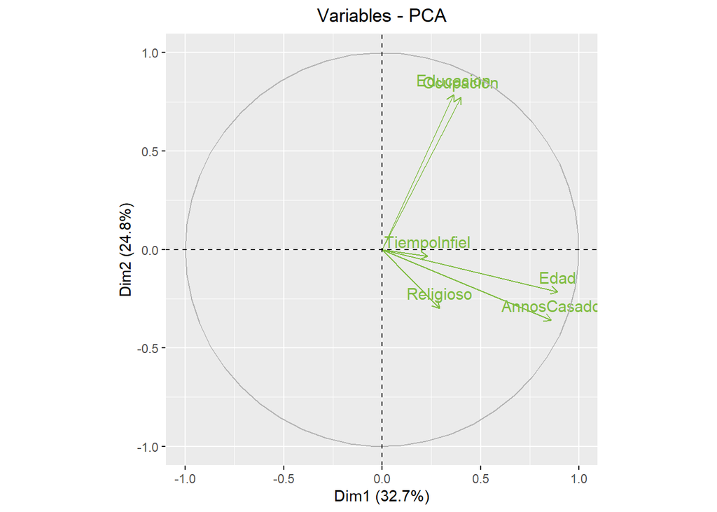

```r
fviz_pca_var(acp.infieles, col.var = "#7FBC41", ggtheme = mi.tema)
```

Dé una interpretación siguiendo los siguientes pasos:

1. Elimine de los gráficos individuos y variables con menos del 5 % de calidad de representación.

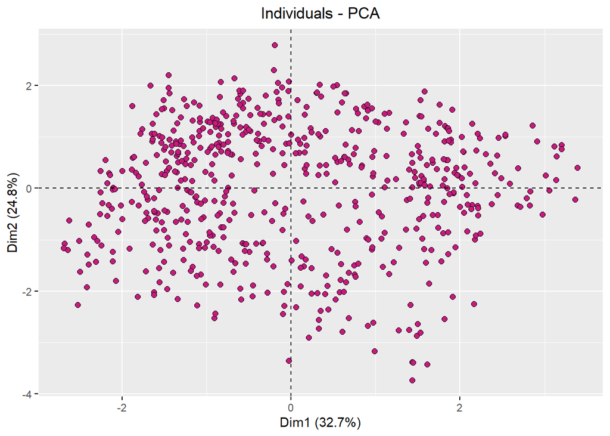

```r
fviz_pca_ind(acp.infieles, pointsize = 2, pointshape = 21, fill = "#C51B7D", repel = TRUE,ggtheme = mi.tema, label = "none", select.ind = list(cos2 = 0.05))
```

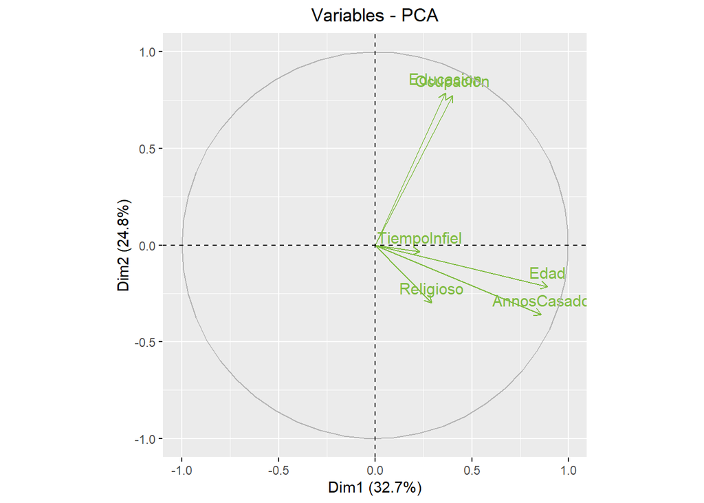

```r
fviz_pca_var(acp.infieles, col.var = "#7FBC41", ggtheme = mi.tema, select.var = list(cos2 = 0.05))
```

2. En el plano principal encuentre 4 clústeres.

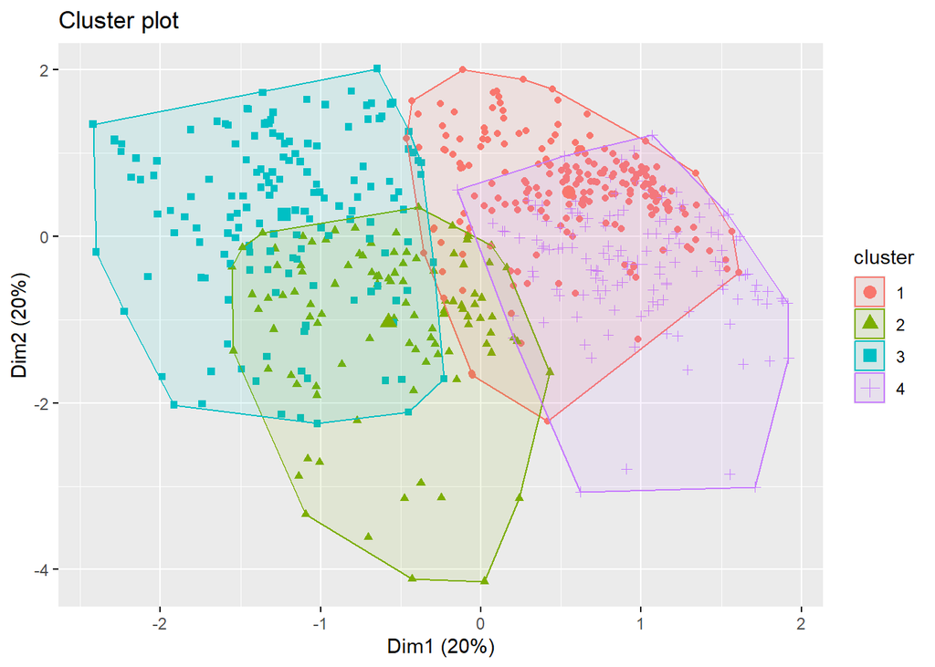

```r
clust <- kmeans(acp.infieles$ind$coord, centers = 4) # 4 clusters

fviz_cluster(clust, geom = "point", data = acp.infieles$ind$coord, ellipse.alpha = 0.1)
```

#### Ejercicio 2.d

Ahora convierta las variables Género e Hijos en Código Disyuntivo Completo y repita el ACP ¿Se gana interpretabilidad al convetir Género e Hijos en Código Disyuntivo Completo?

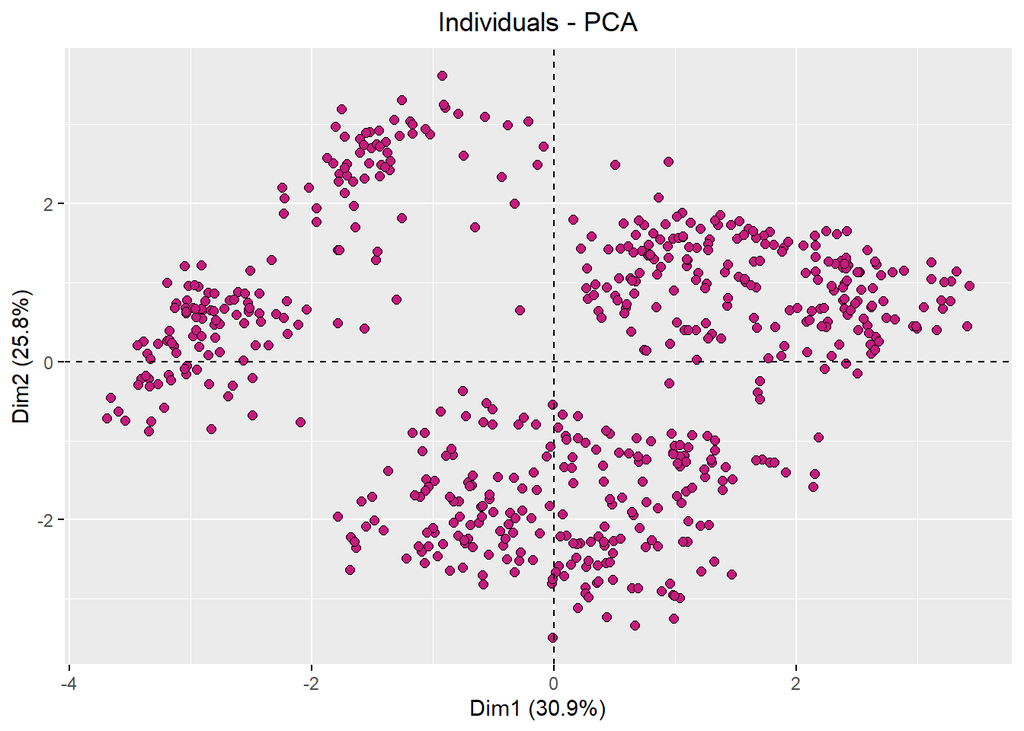

```r
datos.infieles.2 <- read.table("./DatosTarea3/TablaAffairs.csv", header = TRUE, sep = ";",dec='.', stringsAsFactors = TRUE)
datos.infieles.2 <- datos.infieles.2[,-c(1, 10)]

datos.infieles.nuevos <- fastDummies::dummy_cols(datos.infieles.2, select_columns = c("Genero", "Hijos"
                                            ), remove_first_dummy = FALSE, remove_selected_columns = TRUE)

acp.infieles.nuevo <- PCA(datos.infieles.nuevos, scale.unit = TRUE, ncp = 5, graph = FALSE)

fviz_pca_ind(acp.infieles.nuevo, pointsize = 2, pointshape = 21, fill = "#C51B7D", repel = TRUE,ggtheme = mi.tema, label = "none", select.ind = list(cos2 = 0.05))
```

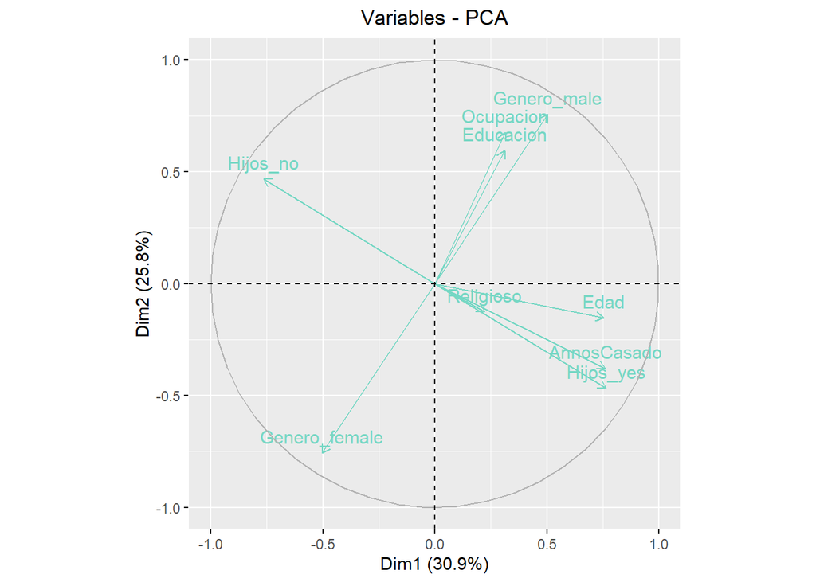

```r
fviz_pca_var(acp.infieles.nuevo, col.var = "#76d7c4", ggtheme = mi.tema, select.var = list(cos2 = 0.05))
```

R/ Sí, los datos están mejor distribuidos y son mucho más fácil de interpretar.

## Parte III

En este ejercicio vamos a realizar un ACP para la tabla SAheart.csv la cual contiene variables numéricas y categóricas mezcladas.

#### Ejercicio 3.a

Efectúe un ACP usando solo las variables numéricas

```r
datos.SAheart <- read.table("./DatosTarea3/SAheart.csv", header = TRUE, sep = ";",dec='.', stringsAsFactors = TRUE)
#Quitamos categóricas
datos.SAheart <- datos.SAheart[,-c(5, 10)]
```

Dé una interpretación siguiendo los siguientes pasos (para todos los ejercicios elimine de los gráficos individuos y variables con menos del 5 % de calidad de representación):

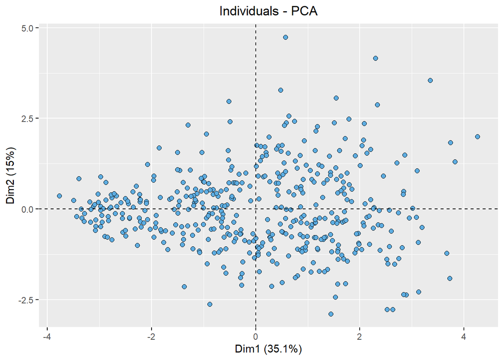

```r
acp.SAheart <- PCA(datos.SAheart, scale.unit = TRUE, ncp = 5, graph = FALSE)

fviz_pca_ind(acp.SAheart, pointsize = 2, pointshape = 21, fill = "#5dade2", repel = TRUE,ggtheme = mi.tema, label = "none", select.ind = list(cos2 = 0.05))
```

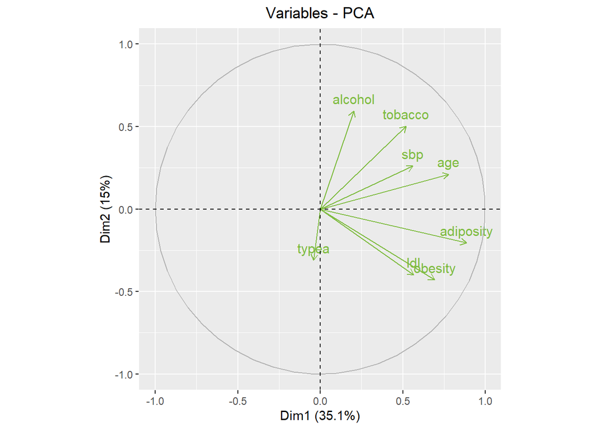

```r
fviz_pca_var(acp.SAheart, col.var = "#7FBC41", ggtheme = mi.tema, select.var = list(cos2 = 0.05))
```

1. En el plano principal encuentre los clústeres.

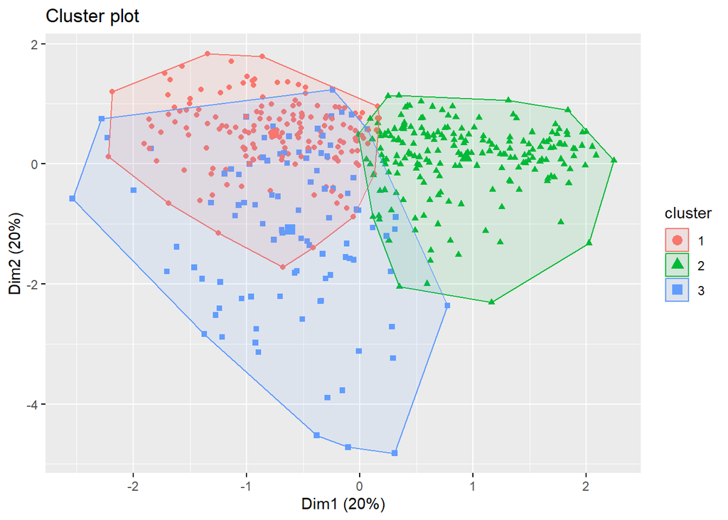

```r
clust <- kmeans(acp.SAheart$ind$coord, centers = 3) # 3 clusters

fviz_cluster(clust, geom = "point", data = acp.SAheart$ind$coord, ellipse.alpha = 0.1)
```

2. En el círculo de correlación determine la correlación entre las variables.
   - Alcohol está muy correlacionado positivamente con tabaco.
   - Tobacco está muy correlacionado positivamente con sbp.
   - Edad tiene correlación positiva con sbp y adiposidad. A mayor edad, mayor presión arterial y mayor adiposidad.
   - Obesidad está fuertemente correlacionada con adiposidad y con ldl. Mayor obesidad se asocia con mayor adiposidad y colesterol LDL.
   - Typea tiene correlación negativa con alcohol.
3. Explique la formación de los clústeres basado en la sobre-posición del círculo y el plano.
   - Clúster rojo: Este clúster agrupa a individuos con mayor consumo en alcohol y tobacco.
   - Clúster verde: Correlacionado negativamente con la mayoría de las variables. Representa a individuos más jóvenes, con menos factores de riesgo en general.
   - Clúster azul: Representa individuos de mayor edad con mayores niveles de adiposidad, obesidad y LDL.

#### Ejercicio 3.b

Efectúe un ACP usando las variables numéricas y las variables categóricas (recuerde recodificar las categóricas usando código disyuntivo completo).

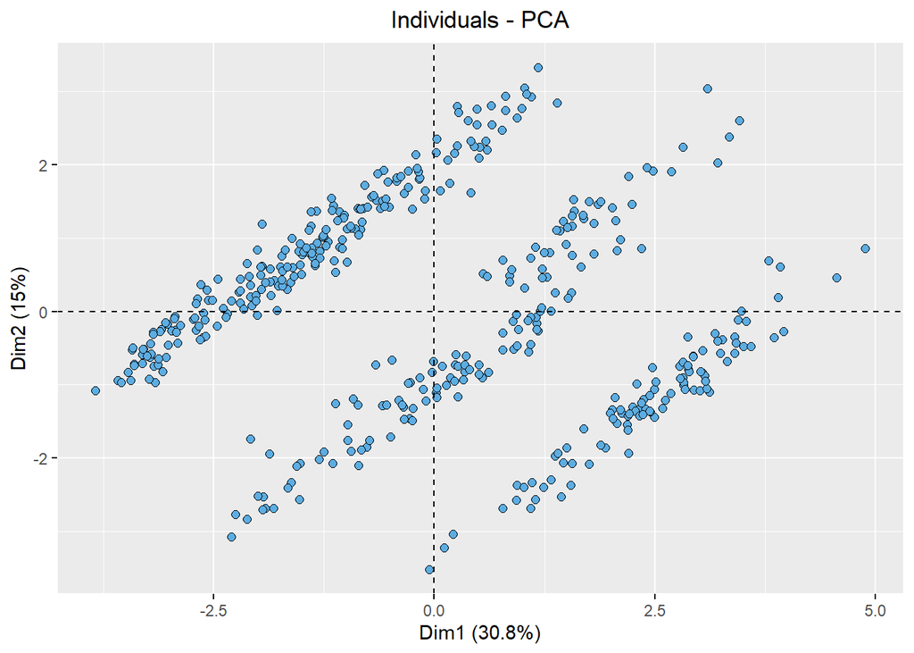

```r
datos.SAheart.2 <- read.table("./DatosTarea3/SAheart.csv", header = TRUE, sep = ";",dec='.', stringsAsFactors = TRUE)

datos.SAheart.nuevo <- fastDummies::dummy_cols(datos.SAheart.2, select_columns = c("famhist", "chd"
                                            ), remove_first_dummy = FALSE, remove_selected_columns = TRUE)

acp.SAheart.nuevo <- PCA(datos.SAheart.nuevo, scale.unit = TRUE, ncp = 5, graph = FALSE)

fviz_pca_ind(acp.SAheart.nuevo, pointsize = 2, pointshape = 21, fill = "#5dade2", repel = TRUE,ggtheme = mi.tema, label = "none", select.ind = list(cos2 = 0.05))
```

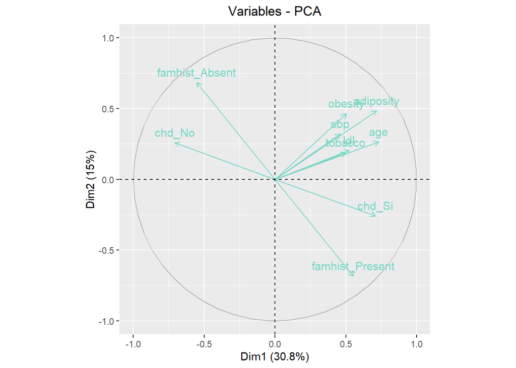

```r
fviz_pca_var(acp.SAheart.nuevo, col.var = "#76d7c4", ggtheme = mi.tema, select.var = list(cos2 = 0.05))
```

Dé una interpretación siguiendo los siguientes pasos:

1. En el plano principal encuentre los clústeres.

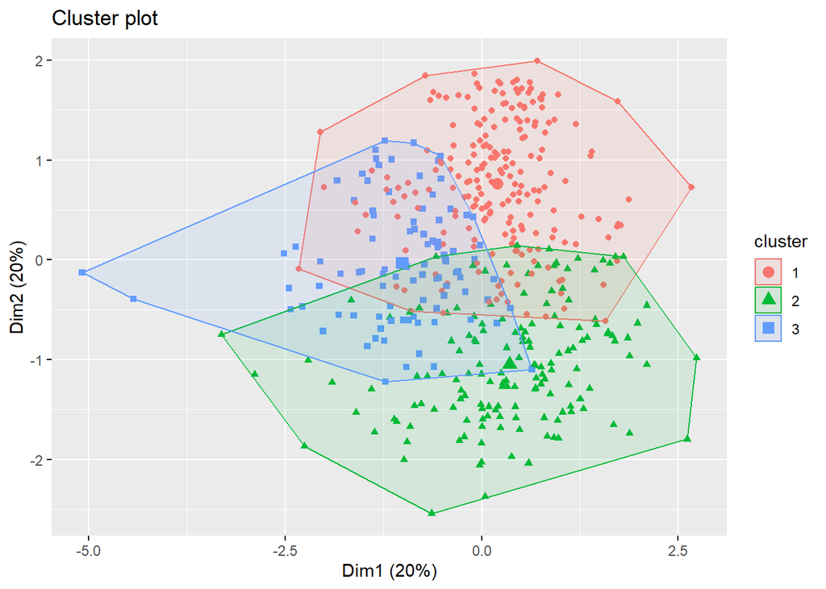

```r
clust <- kmeans(acp.SAheart.nuevo$ind$coord, centers = 3) # 3 clusters

fviz_cluster(clust, geom = "point", data = acp.SAheart.nuevo$ind$coord, ellipse.alpha = 0.1)
```

Podemos notar los tres clústeres que se pueden interpretar de una manera más sencilla.

R/ El segundo ACP ofrece una visión más completa, ya que, en este caso, las variable categorías son relevantes en el contexto de los datos. No solo muestra cómo se relacionan las variables numéricas, sino que también muestra cómo las categorías influyen en la distribución de los datos. Al incluir una variable categórica, es más fácil ver cómo se agrupan los datos en el espacio y ayuda a identificar de manera más sencilla los patrones.